# Hantavirus Clinical Study Report

## Patient 7001

**Sex:** Male | **Age:** 45.8 yrs | **BMI:** 26.5 kg/m² | **Admitted:** Yes | **HCW:** No

**Onset:** 27 May 2026 | **First consultation:** 21 May 2026 | **Admission:** 21 May 2026

**Symptoms at admission:** *None recorded*

**Comorbidities:** *None recorded*

**Exposure history:** Travel outside home region, Contact with confirmed/suspected case *(Travel: He was on the Hondius Cruise)*

**Complications:** Anaemia

**Day 1 Laboratory Results** *(date: 21 May 2026)*

**Day 1 Labs**

| Parameter | Value |
| --- | --- |
| Hb (g/dL) | 8.50 |
| WBC (10^9/L) | 7.50 |
| Neut (10^9/L) | 4.29 |
| Lymph (10^9/L) | 2.21 |
| Eosino (10^9/L) | 0.15 |
| Plt (10^9/L) | 193.00 |
| Hct (%) | 41.00 |
| MCV (fL) | 85.00 |
| ALT (U/L) | 20.00 |
| ALP (U/L) | 77.00 |
| GGT (U/L) | 19.00 |
| Glucose (mmol/L) | 5.00 |
| BUN (mmol/L) | 6.70 |
| Creat (umol/L) | 84.00 |
| Na (mmol/L) | 140.00 |
| K (mmol/L) | 3.80 |

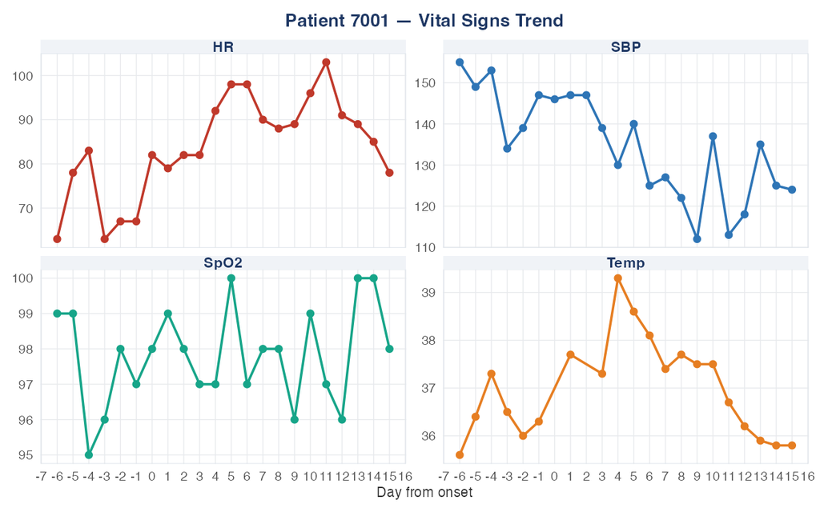

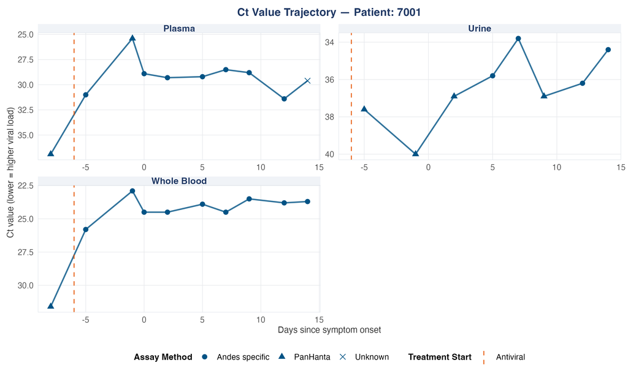

**Respiratory support used:** *None recorded*

**Medications:** Ribavirin (Antiviral); Ribavirin (Antiviral); Enoxaparin (Anticoagulant)

**Outcome:** Discharged alive | 11 Jun 2026 | Self-care: Same as before

## Patient 9001

**Sex:** Male | **Age:** 65.3 yrs | **BMI:** 34.1 kg/m² | **Admitted:** Yes | **HCW:** No

**Onset:** 29 Apr 2026 | **First consultation:** 29 Apr 2026 | **Admission:** 29 Apr 2026

**Symptoms at admission:** Fever, Chills / Rigors, Fatigue, Weakness, Myalgia, Cough, Shortness of Breath, Abdominal Pain, Diarrhoea, Anorexia, Headache

**Comorbidities:** Hypertension, Obesity, Diabetes, Ever Smoked, Malignancy, Radiotherapy

**Exposure history:** Travel outside home region, Contact with confirmed/suspected case *(Travel: Johannesburg Ushaia Falkland Islands South Georgia)*

**Complications:** *None recorded*

**Day 1 Laboratory Results** *(date: 02 May 2026)*

**Day 1 Labs**

| Parameter | Value |
| --- | --- |
| Hb (g/dL) | 16.20 |
| WBC (10^9/L) | 7.90 |
| Neut (10^9/L) | 6.56 |
| Lymph (10^9/L) | 0.53 |
| Eosino (10^9/L) | 0.16 |
| Plt (10^9/L) | 106.00 |
| MCV (fL) | 87.80 |

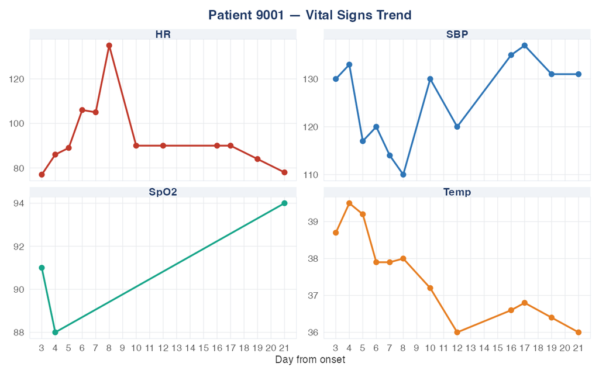

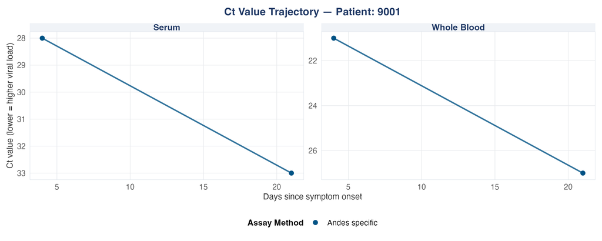

**Respiratory support used:** Supplemental O2, Nasal Prongs, Face Mask

**Medications:** Dexamethasone (Corticosteroid); Other (Antibiotic)

**Outcome:** Discharged alive | 20 May 2026 | Self-care: Same as before